# Chapter 3. Logistic regression

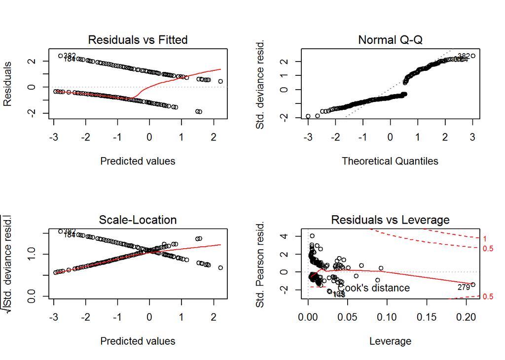

```r
# bm6 is the best fit based, preprosessed parameters by centering and scaling, then using feature selection using LASSO with 10-fold crossvalidation , removing confounding parameters.
# The model was further validated with stepwise forward and backward selection and confirmed checking the Akaike information criteria.
par(mfrow=c(2,2))
plot(bm6)
```

```r
# The model validation is bit more tricky with binomial models, you won't see such neat plots unless the number of observations is very high (N > 400). In this case plots look ok.


# These are loaded only now, since they mask some functions from dplyr
library(MASS)
library(fitdistrplus)
alc_num <- as.numeric(alc$high_use)
fitBinom=fitdist(data=alc_num, dist="binom", fix.arg=list(size=2), start=list(prob=0.3))
plot(pnbinom(sort(alc_num), size=2, mu=fitBinom$estimate), ppoints(alc_num))
abline(0,1)
# This shows the estimated binomial distribution in our response variable.

# compute odds ratios (OR)
OR <- coef(bm6) %>% exp
# compute confidence intervals (CI)
CI <- exp(confint(bm6))
cbind(OR, CI)
```

[output not shown]

```
##                     OR     2.5 %     97.5 %
## (Intercept) 0.02593937 0.0107041 0.05891273
## failures    1.51447465 1.0137625 2.27486120
## absences    1.07838996 1.0341084 1.12889344
## goout       2.04033617 1.6296451 2.58472531
```

```r
# predictions
pred.bm6 <- predict(bm6, type = "response")

# add the predicted probabilities to 'alc'
alc <- mutate(alc, probability = pred.bm6)

# use the probabilities to make a prediction of high_use
alc <- mutate(alc, prediction = pred.bm6 > 0.5)

# see the last ten original classes, predicted probabilities, and class predictions
alc[36:38] %>% tail(10)
```

```
##     high_use probability prediction
## 373    FALSE  0.14055409      FALSE
## 374     TRUE  0.36139910      FALSE
## 375    FALSE  0.19198237      FALSE
## 376    FALSE  0.25734107      FALSE
## 377    FALSE  0.15979460      FALSE
## 378    FALSE  0.34330586      FALSE
## 379    FALSE  0.22362093      FALSE
## 380    FALSE  0.06224146      FALSE
## 381     TRUE  0.55365666       TRUE
## 382     TRUE  0.05797935      FALSE
```

```r
# initialize a plot of 'high_use' versus 'probability' in 'alc'
g <- ggplot(alc, aes(x = c(high_use), y = probability, color = prediction))

# define the geom as points and draw the plot
g + geom_point()

# tabulate the target variable versus the predictions
table(high_use = alc$high_use, prediction = alc$prediction) %>% prop.table() %>% addmargins()
```

```
##         prediction
## high_use      FALSE       TRUE        Sum
##    FALSE 0.64397906 0.05759162 0.70157068
##    TRUE  0.18062827 0.11780105 0.29842932
##    Sum   0.82460733 0.17539267 1.00000000
```

```r
# how many are correct
sum(alc[36]==alc[38])/382
```

```
## [1] 0.7617801
```

```r
# 76.178 % are correct
1-sum(alc[36]==alc[38])/382
```

```
## [1] 0.2382199
```

```r
# Training error is 23.821 % (DataCamp is 26 %)

# Here is the DataCamp version of training error, (which I find more complicated, but perhaps easier to follow).
# define a loss function (mean prediction error)
loss_func <- function(class, prob) {
  n_wrong <- abs(class - prob) > 0.5
  mean(n_wrong)
}

# call loss_func to compute the average number of wrong predictions in the (training) data
loss_func(class = alc$high_use, prob = alc$probability)
```

```
## [1] 0.2382199
```

```r
# The model is better than the one introduced in DataCamp
```

[figure not shown]

```r
# K-fold cross-validation
library(boot)
cv <- cv.glm(data = alc, cost = loss_func, glmfit = bm6, K = 10)

# average number of wrong predictions in the cross validation
cv$delta[1]
```

```
## [1] 0.2486911
```

Training error is 23.821 % (not validated) (DataCamp is > 26 %) Crossvalidated training error is 24.8699 %

# Other notes

```r
# I found this very useful in the DataCamp exercises

# produce summary statistics by group with piping variable #>#
alc %>% group_by(sex, high_use) %>% summarise(count = n(), mean_grade=mean(G3))
```

[output not shown]

This weeks exercise was interesting. In the end I tried some new methods I haven’t tried before, such as the LASSO feature selection. I wonder how the parameters were selected in the DataCamp exercises? Was the method in any way similar than the LASSO approach I used. I also tested LASSO without the preprosessing and the results differed. That model had much poorer results than the one with preprosessing. I’m curious how that can effect the LASSO results so much.